# Winter skate

Abigail Tyrell

15 Dec 2020

This is a preliminary report of previously collected data. This report is pulling information on all Northeast Winter skate stocks.

# Methods

## General methods

Northeast stocks were identified from NOAA/EDAB ECSA [seasonal species strata](https://github.com/NOAA-EDAB/ECSA/blob/master/data/seasonal_stock_strata.csv).

Data sources for each analysis are identified in the Results.

All continuous temporal data were plotted against time. If there were 30 or more years of data, a geom_gls regression line was fit (yellow = significant increase; purple = significant decrease; no line = no significant trend). If there were fewer than 30 years of data, no regression was fit.

## `assessmentdata` methods

Stock assessment and data quality information were compiled into a summary table.

B/Bmsy was classified as “DANGER” if it was below 1 and “GOOD” if it was above 1.

F/Fmsy was classified as “DANGER” if it was above 1 and “GOOD” if it was below 1.

## `survdat` methods

`survdat` data with zero abundance were not included in this analysis. Abundance and biomass were summed for each year and season. All other metrics were averaged for each year and season. The tables show summary statistics for the entire time series and for the most recent 5 years in the time series.

# Results

## Indicator time series

### Latitude and longitude

Latitude and longitude ranges were compiled from NOAA/EDAB ECSA [seasonal species strata](https://github.com/NOAA-EDAB/ECSA/blob/master/data/seasonal_stock_strata.csv) and [Bottom Trawl Survey (BTS) shapefiles](https://github.com/NOAA-EDAB/ECSA/tree/master/data/strata_shapefiles). The coordinate system is WGS84.

| Region | Season | Lat_min | Long_min | Lat_max | Long_max | Warning |
| --- | --- | --- | --- | --- | --- | --- |
| all | fall | -75.66 | 35.5 | -65.57 | 44.49 | shapefile is missing some strata data |

### Stock assessment and data quality information

Stock assessment and data quality information were pulled from `assessmentdata::stockAssessmentSummary`.

|  | Species | Region | Assessment Year | Last Data Year | Biological Data Rating (2019) | Biological Data Rating (before 2019) | Size Data Rating | Ecosystem Linkage Data Rating | FSSI status | Review Result |
| --- | --- | --- | --- | --- | --- | --- | --- | --- | --- | --- |
| 219 | Winter skate | Georges Bank / Southern New England | 2006 | 2005 | NA | 0 | NA | NA | Y | Accept previous approach, remand new attempt |
| 220 | Winter skate | Georges Bank / Southern New England | 2008 | 2008 | NA | 2 | NA | NA | Y | Full acceptance |
| 221 | Winter skate | Georges Bank / Southern New England | 2009 | 2008 | NA | 2 | NA | NA | Y | Full acceptance |
| 222 | Winter skate | Georges Bank / Southern New England | 2011 | 2010 | NA | 2 | NA | NA | Y | Full acceptance |
| 223 | Winter skate | Georges Bank / Southern New England | 2012 | 2011 | NA | 2 | NA | NA | Y | Full acceptance |
| 224 | Winter skate | Georges Bank / Southern New England | 2013 | 2012 | NA | 2 | NA | NA | Y | Full acceptance |
| 225 | Winter skate | Georges Bank / Southern New England | 2014 | 2013 | NA | 2 | NA | NA | Y | Full acceptance |
| 226 | Winter skate | Georges Bank / Southern New England | 2015 | 2014 | NA | 2 | NA | NA | Y | Full acceptance |
| 227 | Winter skate | Georges Bank / Southern New England | 2016 | 2015 | NA | 2 | NA | NA | Y | Full acceptance |
| 228 | Winter skate | Georges Bank / Southern New England | 2017 | 2016 | NA | 2 | NA | NA | Y | Full acceptance |
| 229 | Winter skate | Georges Bank / Southern New England | 2018 | 2017 | NA | 2 | NA | NA | Y | Full acceptance |
| 240 | Winter skate | Georges Bank / Southern New England | 2019 | 2018 | NA | NA | 1 | 0 | Y | Full acceptance |

### B/Bmsy

B/Bmsy data were pulled from `assessmentdata::stockAssessmentSummary`.

The most recent status of B/Bmsy is: GOOD

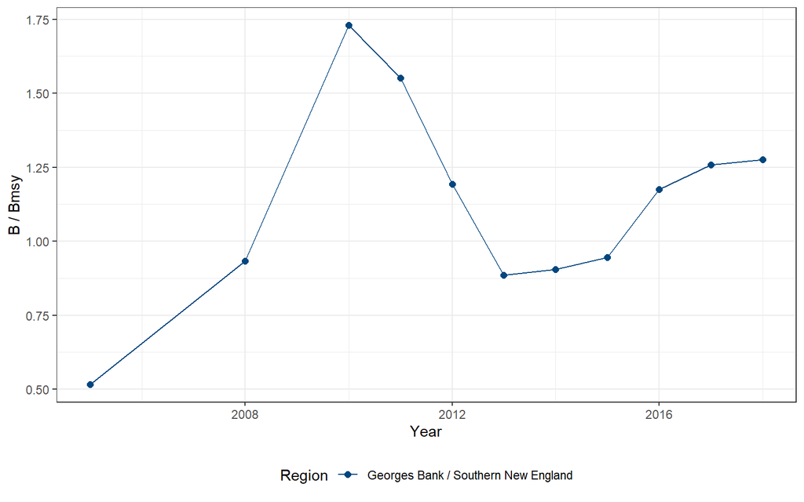

### F/Fmsy

F/Fmsy data were pulled from `assessmentdata::stockAssessmentSummary`.

The most recent status of F/Fmsy is: UNKNOWN

```
## [1] "NO DATA"
```

### Recruitment

Recruitment data were pulled from `assessmentdata::stockAssessmentData`. Separate geom_gls() functions were fit for each region; trend lines are only shown when the trend was statistically significant, so some plots may have fewer trend lines than regions.

```
## [1] "NO DATA"
```

### Diet

Diet data were compiled from [existing data](https://github.com/Laurels1/Condition/blob/master/data/allfh.RData). For analysis, all geographic samples were grouped by season, year, and region, and only year-season-region combinations with more than 20 predators sampled were considered. Prey items that made up more than 5% of the predator’s diet in at least one year-season-region were identified to the broad category level; all other prey are grouped into the “other” category.

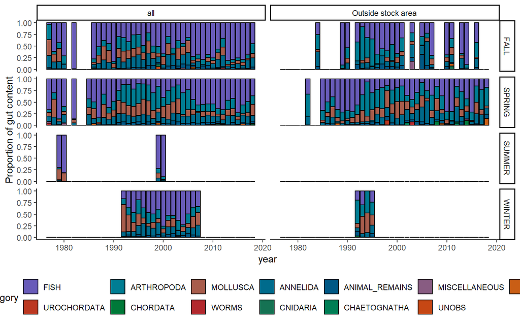

| Prey category | Season | Region | Mean proportion +- SD (n years) | Range |
| --- | --- | --- | --- | --- |
| FISH | FALL | all | 0.538 +- 0.218 (38) | 0.032 - 0.988 |
| FISH | FALL | Outside stock area | 0.482 +- 0.225 (22) | 0.085 - 0.912 |
| FISH | SPRING | all | 0.421 +- 0.22 (39) | 0.096 - 0.862 |
| FISH | SPRING | Outside stock area | 0.369 +- 0.21 (35) | 0.068 - 0.714 |
| FISH | SUMMER | all | 0.784 +- 0.091 (4) | 0.7 - 0.9 |
| FISH | WINTER | all | 0.453 +- 0.167 (16) | 0.165 - 0.759 |
| FISH | WINTER | Outside stock area | 0.245 +- 0.053 (3) | 0.195 - 0.3 |
| ARTHROPODA | FALL | all | 0.132 +- 0.078 (38) | 0.01 - 0.331 |
| ARTHROPODA | FALL | Outside stock area | 0.235 +- 0.181 (22) | 0.035 - 0.724 |
| ARTHROPODA | SPRING | all | 0.228 +- 0.127 (39) | 0.014 - 0.479 |
| ARTHROPODA | SPRING | Outside stock area | 0.277 +- 0.128 (35) | 0.109 - 0.736 |
| ARTHROPODA | SUMMER | all | 0.046 +- 0.038 (4) | 0.003 - 0.093 |
| ARTHROPODA | WINTER | all | 0.166 +- 0.073 (16) | 0.046 - 0.307 |
| ARTHROPODA | WINTER | Outside stock area | 0.375 +- 0.133 (4) | 0.245 - 0.503 |
| MOLLUSCA | FALL | all | 0.143 +- 0.092 (37) | 0.001 - 0.341 |
| MOLLUSCA | FALL | Outside stock area | 0.065 +- 0.045 (20) | 0.001 - 0.159 |
| MOLLUSCA | SPRING | all | 0.16 +- 0.1 (39) | 0.03 - 0.386 |
| MOLLUSCA | SPRING | Outside stock area | 0.147 +- 0.094 (35) | 0.002 - 0.358 |
| MOLLUSCA | SUMMER | all | 0.134 +- 0.096 (4) | 0.01 - 0.232 |
| MOLLUSCA | WINTER | all | 0.181 +- 0.142 (16) | 0.008 - 0.591 |
| MOLLUSCA | WINTER | Outside stock area | 0.277 +- 0.149 (4) | 0.094 - 0.419 |
| ANNELIDA | FALL | all | 0.147 +- 0.076 (38) | 0.002 - 0.277 |
| ANNELIDA | FALL | Outside stock area | 0.151 +- 0.112 (22) | 0.017 - 0.515 |
| ANNELIDA | SPRING | all | 0.145 +- 0.045 (39) | 0.025 - 0.238 |
| ANNELIDA | SPRING | Outside stock area | 0.149 +- 0.099 (35) | 0.022 - 0.491 |
| ANNELIDA | SUMMER | all | 0.029 +- 0.026 (4) | 0.005 - 0.065 |
| ANNELIDA | WINTER | all | 0.152 +- 0.066 (16) | 0.062 - 0.283 |
| ANNELIDA | WINTER | Outside stock area | 0.108 +- 0.05 (4) | 0.072 - 0.18 |
| ANIMAL_REMAINS | FALL | all | 0.035 +- 0.026 (37) | 0 - 0.09 |
| ANIMAL_REMAINS | FALL | Outside stock area | 0.058 +- 0.067 (22) | 0.001 - 0.318 |
| ANIMAL_REMAINS | SPRING | all | 0.035 +- 0.022 (38) | 0.002 - 0.083 |
| ANIMAL_REMAINS | SPRING | Outside stock area | 0.032 +- 0.025 (35) | 0 - 0.083 |
| ANIMAL_REMAINS | SUMMER | all | 0.005 +- 0.005 (4) | 0.001 - 0.012 |
| ANIMAL_REMAINS | WINTER | all | 0.043 +- 0.022 (16) | 0.012 - 0.087 |
| ANIMAL_REMAINS | WINTER | Outside stock area | 0.046 +- 0.048 (4) | 0.002 - 0.1 |
| MISCELLANEOUS | FALL | all | 0.005 +- 0.006 (20) | 0 - 0.026 |
| MISCELLANEOUS | FALL | Outside stock area | 0.09 +- 0.122 (2) | 0.004 - 0.176 |
| MISCELLANEOUS | SPRING | all | 0.008 +- 0.011 (19) | 0 - 0.046 |
| MISCELLANEOUS | SPRING | Outside stock area | 0.007 +- 0.012 (9) | 0 - 0.035 |
| MISCELLANEOUS | SUMMER | all | 0.002 +- 0.002 (3) | 0 - 0.005 |
| MISCELLANEOUS | WINTER | all | 0.002 +- 0.005 (8) | 0 - 0.014 |
| MISCELLANEOUS | WINTER | Outside stock area | 0.003 +- NA (1) | 0.003 - 0.003 |
| OTHER | FALL | all | 0.004 +- 0.01 (17) | 0 - 0.04 |
| OTHER | FALL | Outside stock area | 0.009 +- 0.021 (6) | 0 - 0.052 |
| OTHER | SPRING | all | 0.008 +- 0.012 (24) | 0 - 0.048 |
| OTHER | SPRING | Outside stock area | 0.016 +- 0.036 (17) | 0 - 0.148 |
| OTHER | SUMMER | all | 0 +- 0 (2) | 0 - 0 |
| OTHER | WINTER | all | 0.002 +- 0.003 (10) | 0 - 0.01 |
| OTHER | WINTER | Outside stock area | 0 +- NA (1) | 0 - 0 |
| UROCHORDATA | FALL | all | 0.005 +- 0.007 (2) | 0 - 0.01 |
| UROCHORDATA | SPRING | Outside stock area | 0.034 +- 0.059 (3) | 0 - 0.102 |
| UROCHORDATA | WINTER | all | 0.008 +- NA (1) | 0.008 - 0.008 |
| UROCHORDATA | WINTER | Outside stock area | 0.006 +- NA (1) | 0.006 - 0.006 |
| CHORDATA | FALL | all | 0.003 +- NA (1) | 0.003 - 0.003 |
| CHORDATA | SPRING | all | 0.009 +- 0.016 (4) | 0 - 0.033 |
| CHORDATA | SPRING | Outside stock area | 0.028 +- 0.042 (8) | 0.001 - 0.098 |
| CHORDATA | WINTER | all | 0.01 +- 0.01 (2) | 0.004 - 0.017 |
| CHORDATA | WINTER | Outside stock area | 0.032 +- NA (1) | 0.032 - 0.032 |
| WORMS | FALL | all | 0.005 +- 0.008 (9) | 0 - 0.026 |
| WORMS | FALL | Outside stock area | 0.001 +- NA (1) | 0.001 - 0.001 |
| WORMS | SPRING | all | 0.005 +- 0.012 (16) | 0 - 0.048 |
| WORMS | SPRING | Outside stock area | 0.014 +- 0.028 (7) | 0 - 0.077 |
| WORMS | SUMMER | all | 0 +- 0 (3) | 0 - 0 |
| WORMS | WINTER | all | 0.004 +- 0.001 (3) | 0.003 - 0.005 |
| CNIDARIA | FALL | all | 0.008 +- 0.017 (11) | 0 - 0.057 |
| CNIDARIA | FALL | Outside stock area | 0.026 +- 0.036 (3) | 0.001 - 0.067 |
| CNIDARIA | SPRING | all | 0.003 +- 0.007 (13) | 0 - 0.025 |
| CNIDARIA | SPRING | Outside stock area | 0.001 +- 0.001 (3) | 0 - 0.002 |
| CNIDARIA | SUMMER | all | 0.001 +- 0 (2) | 0.001 - 0.001 |
| CNIDARIA | WINTER | all | 0.004 +- 0.004 (2) | 0.001 - 0.006 |
| CHAETOGNATHA | SPRING | all | 0.003 +- 0.004 (9) | 0 - 0.009 |
| CHAETOGNATHA | SPRING | Outside stock area | 0.024 +- 0.029 (5) | 0 - 0.063 |
| CHAETOGNATHA | WINTER | all | 0.005 +- NA (1) | 0.005 - 0.005 |
| UNOBS | FALL | all | 0.054 +- NA (1) | 0.054 - 0.054 |
| UNOBS | WINTER | all | 0.003 +- NA (1) | 0.003 - 0.003 |

### Temperature

#### Surface temperature

Surface temperature data were pulled from `survdat`. Separate geom_gls() functions were fit for fall and spring measurements; trend lines are only shown when the trend was statistically significant, so some plots may have fewer than two trend lines. Fall has solid trend lines, and spring has dashed trend lines. Please note, sometimes the survey observed a small number of fish outside of the defined stock area.

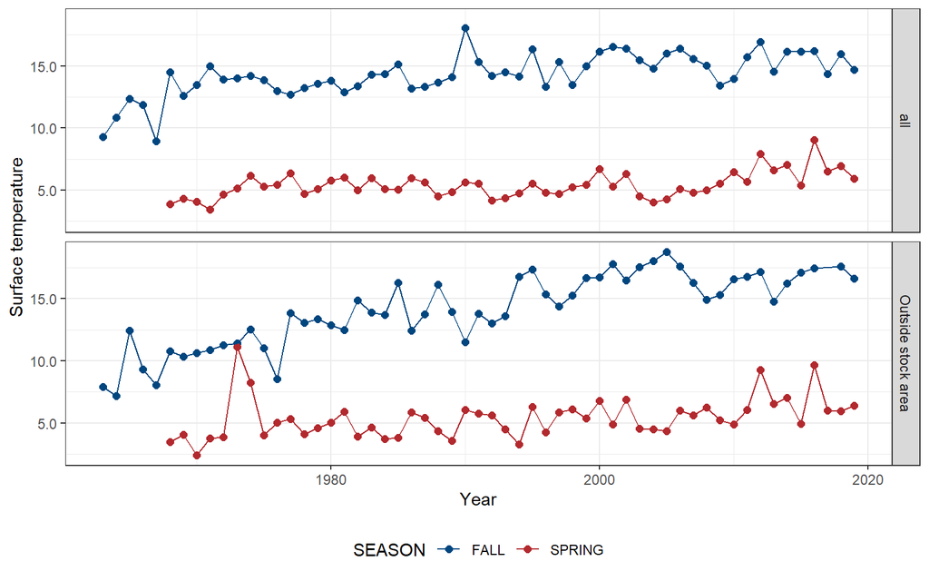

| Season | Region | Mean value +- SD (n years) | Mean value +- SD (past 5 years) | Range (total) | Range (past 5 years) |
| --- | --- | --- | --- | --- | --- |
| FALL | all | 14.31 +- 1.7 (57) | 15.47 +- 0.89 (5) | 8.96 - 18.07 | 14.33 - 16.2 |
| FALL | Outside stock area | 14.11 +- 2.92 (56) | 17.2 +- 0.43 (4) | 7.2 - 18.78 | 16.61 - 17.58 |
| SPRING | all | 5.42 +- 1.03 (52) | 6.76 +- 1.41 (5) | 3.45 - 9.04 | 5.37 - 9.04 |
| SPRING | Outside stock area | 5.41 +- 1.62 (52) | 6.59 +- 1.8 (5) | 2.4 - 11.1 | 4.91 - 9.67 |

#### Bottom temperature

Bottom temperature data were pulled from `survdat`. Separate geom_gls() functions were fit for fall and spring measurements; trend lines are only shown when the trend was statistically significant, so some plots may have fewer than two trend lines. Fall has solid trend lines, and spring has dashed trend lines. Please note, sometimes the survey observed a small number of fish outside of the defined stock area.

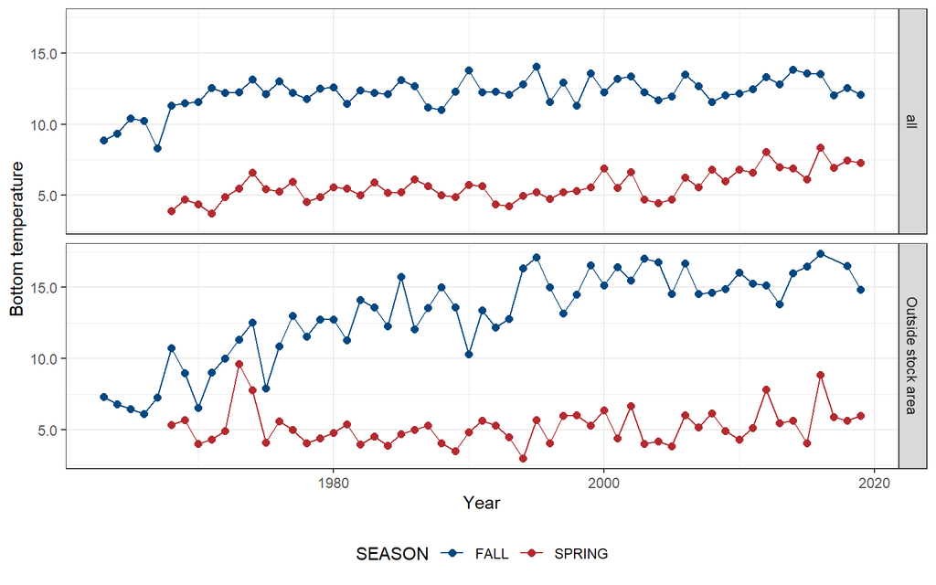

| Season | Region | Mean value +- SD (n years) | Mean value +- SD (past 5 years) | Range (total) | Range (past 5 years) |
| --- | --- | --- | --- | --- | --- |
| FALL | all | 12.17 +- 1.14 (57) | 12.75 +- 0.75 (5) | 8.29 - 14.02 | 12.02 - 13.57 |
| FALL | Outside stock area | 13.08 +- 3.15 (56) | 16.3 +- 1.06 (4) | 6.1 - 17.39 | 14.84 - 17.39 |
| SPRING | all | 5.66 +- 1.03 (52) | 7.23 +- 0.81 (5) | 3.73 - 8.36 | 6.14 - 8.36 |
| SPRING | Outside stock area | 5.21 +- 1.27 (52) | 6.09 +- 1.73 (5) | 2.99 - 9.61 | 4.07 - 8.85 |

### Salinity

#### Surface salinity

Surface salinity data were pulled from `survdat`. Separate geom_gls() functions were fit for fall and spring measurements; trend lines are only shown when the trend was statistically significant, so some plots may have fewer than two trend lines. Fall has solid trend lines, and spring has dashed trend lines. Please note, sometimes the survey observed a small number of fish outside of the defined stock area.

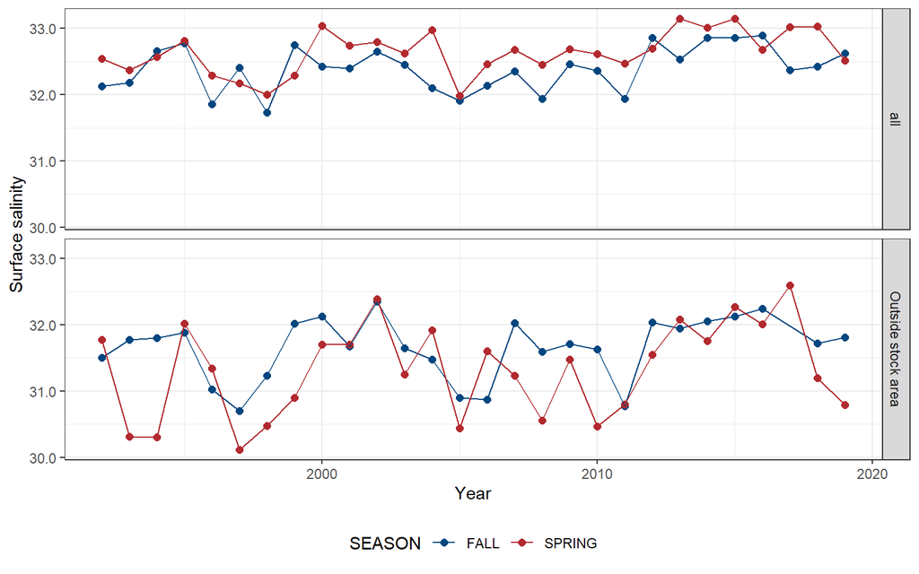

| Season | Region | Mean value +- SD (n years) | Mean value +- SD (past 5 years) | Range (total) | Range (past 5 years) |
| --- | --- | --- | --- | --- | --- |
| FALL | all | 32.39 +- 0.34 (28) | 32.64 +- 0.24 (5) | 31.73 - 32.89 | 32.37 - 32.89 |
| FALL | Outside stock area | 31.65 +- 0.46 (27) | 31.98 +- 0.25 (4) | 30.7 - 32.35 | 31.72 - 32.24 |
| SPRING | all | 32.64 +- 0.32 (28) | 32.88 +- 0.27 (5) | 31.99 - 33.15 | 32.51 - 33.14 |
| SPRING | Outside stock area | 31.32 +- 0.71 (28) | 31.77 +- 0.75 (5) | 30.11 - 32.59 | 30.79 - 32.59 |

#### Bottom salinity

Bottom salinity data were pulled from `survdat`. Separate geom_gls() functions were fit for fall and spring measurements; trend lines are only shown when the trend was statistically significant, so some plots may have fewer than two trend lines. Fall has solid trend lines, and spring has dashed trend lines. Please note, sometimes the survey observed a small number of fish outside of the defined stock area.

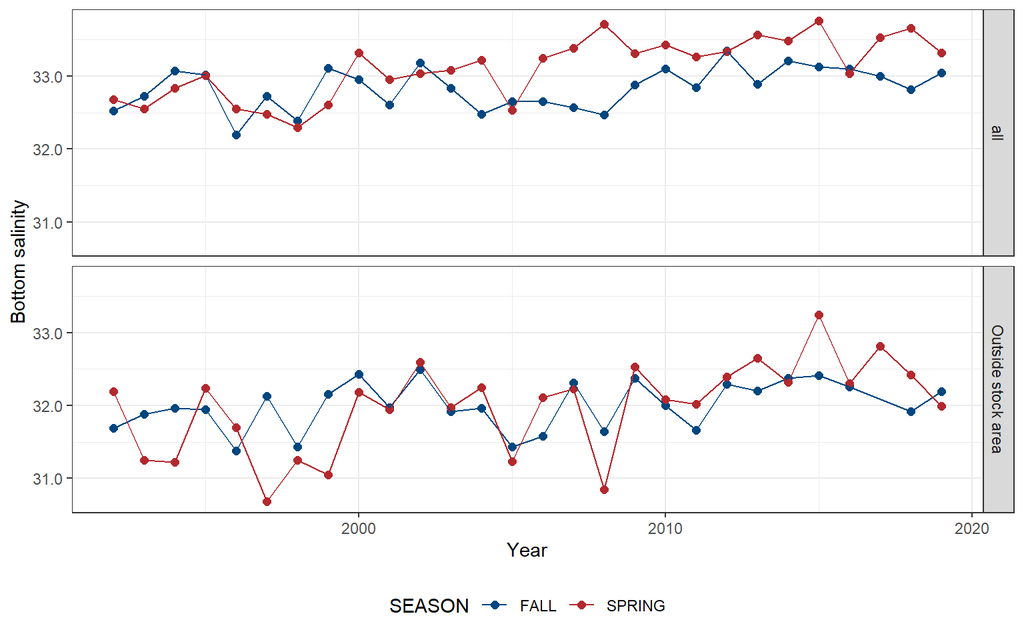

| Season | Region | Mean value +- SD (n years) | Mean value +- SD (past 5 years) | Range (total) | Range (past 5 years) |
| --- | --- | --- | --- | --- | --- |
| FALL | all | 32.84 +- 0.28 (28) | 33.02 +- 0.12 (5) | 32.2 - 33.35 | 32.82 - 33.13 |
| FALL | Outside stock area | 32 +- 0.33 (27) | 32.19 +- 0.21 (4) | 31.38 - 32.49 | 31.92 - 32.41 |
| SPRING | all | 33.11 +- 0.41 (28) | 33.46 +- 0.29 (5) | 32.3 - 33.76 | 33.03 - 33.76 |
| SPRING | Outside stock area | 31.99 +- 0.62 (28) | 32.56 +- 0.48 (5) | 30.68 - 33.24 | 31.99 - 33.24 |

### Abundance

#### `survdat`

Abundance data were pulled from `survdat`. Separate geom_gls() functions were fit for fall and spring measurements; trend lines are only shown when the trend was statistically significant, so some plots may have fewer than two trend lines. Fall has solid trend lines, and spring has dashed trend lines. Please note, sometimes the survey observed a small number of fish outside of the defined stock area.

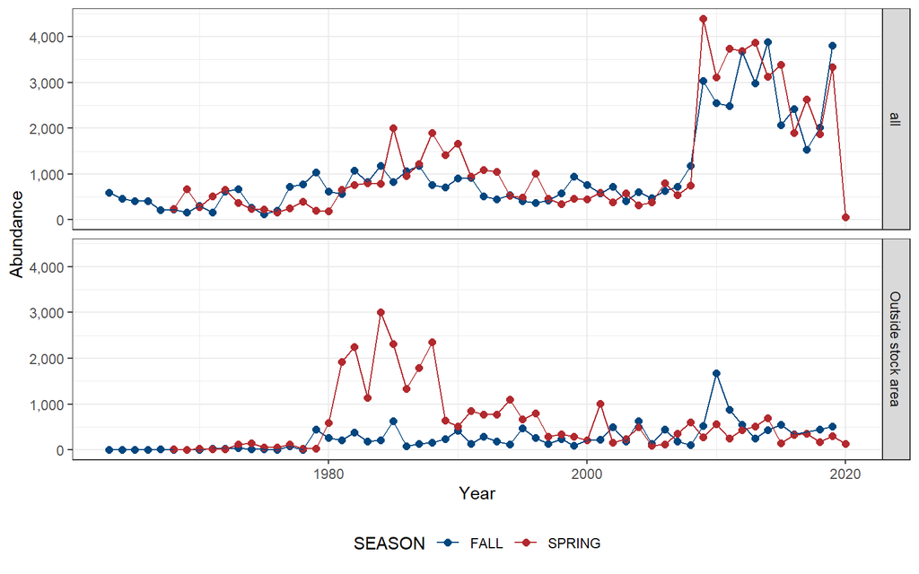

| Season | Region | Mean value +- SD (n years) | Mean value +- SD (past 5 years) | Range (total) | Range (past 5 years) |
| --- | --- | --- | --- | --- | --- |
| FALL | all | 1,031.88 +- 953.64 (57) | 2,369 +- 858.74 (5) | 125 - 3,886 | 1,539 - 3,799 |
| FALL | Outside stock area | 255.48 +- 283.23 (56) | 464.75 +- 90.08 (4) | 1 - 1,677 | 347 - 556 |
| SPRING | all | 1,186.28 +- 1,162.82 (53) | 1,960.2 +- 1,219.84 (5) | 61 - 4,393 | 61 - 3,334 |
| SPRING | Outside stock area | 600.15 +- 695.11 (53) | 258.8 +- 96.15 (5) | 3 - 3,008 | 136 - 353 |

#### `assessmentdata`

Abundance data were pulled from `assessmentdata::stockAssessmentData`. Separate geom_gls() functions were fit for each region; trend lines are only shown when the trend was statistically significant, so some plots may have fewer trend lines than regions.

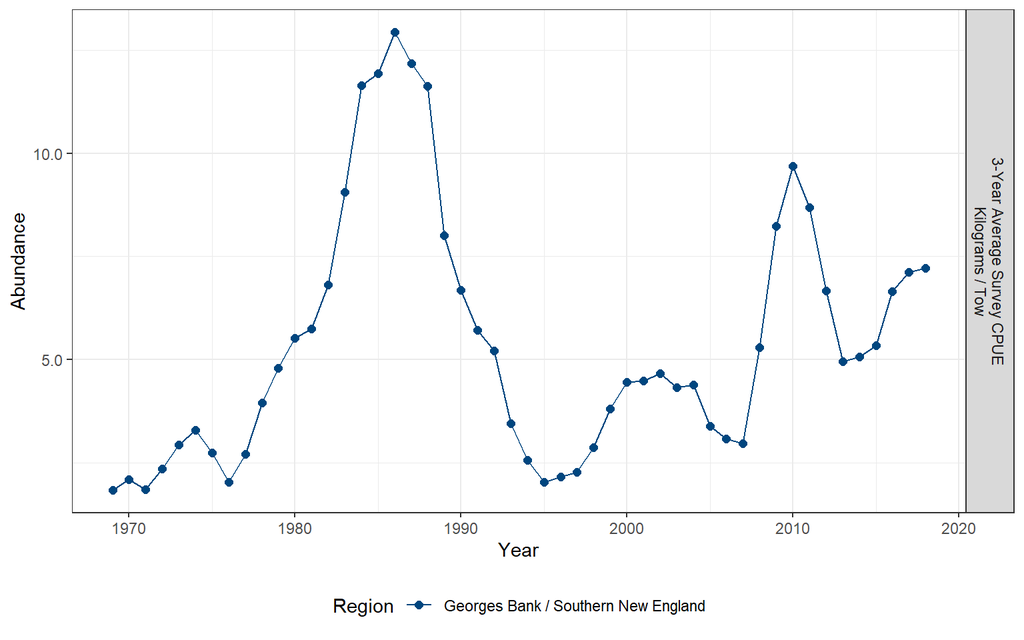

### Biomass

Biomass data were pulled from `survdat`. Separate geom_gls() functions were fit for fall and spring measurements; trend lines are only shown when the trend was statistically significant, so some plots may have fewer than two trend lines. Fall has solid trend lines, and spring has dashed trend lines. Please note, sometimes the survey observed a small number of fish outside of the defined stock area.

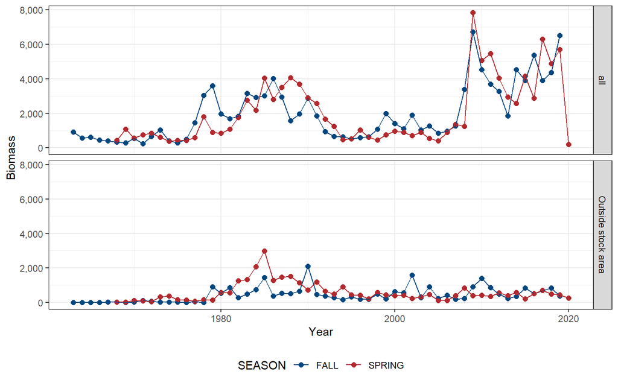

| Season | Region | Mean value +- SD (n years) | Mean value +- SD (past 5 years) | Range (total) | Range (past 5 years) |
| --- | --- | --- | --- | --- | --- |
| FALL | all | 2,001.98 +- 1,626.89 (57) | 4,814.59 +- 1,123.55 (5) | 236.1 - 6,718.78 | 3,896.58 - 6,512.47 |
| FALL | Outside stock area | 437.97 +- 445.17 (56) | 640.53 +- 234.29 (4) | 0.5 - 2,105.2 | 378.52 - 843.78 |
| SPRING | all | 2,036.08 +- 1,825.61 (53) | 3,992.68 +- 2,490.38 (5) | 184.3 - 7,847.08 | 184.3 - 6,304.77 |
| SPRING | Outside stock area | 578.47 +- 552.45 (53) | 480.77 +- 160.61 (5) | 21.3 - 2,980.4 | 257.66 - 705.31 |

### Catch

#### Catch

Catch statistics from `assessmentdata::stockAssessmentData`.

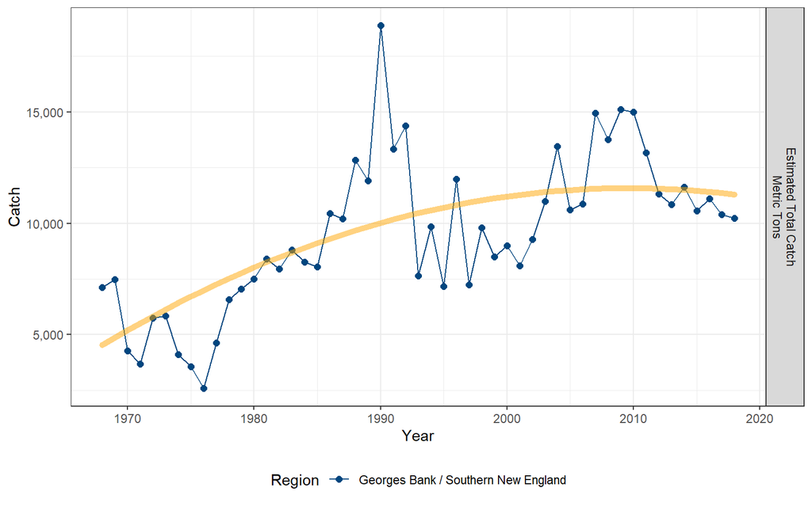

#### Recreational catch

Recreational catch data were downloaded from [NOAA MRIP](https://www.st.nmfs.noaa.gov/st1/recreational/MRIP_Estimate_Data/CSV/).

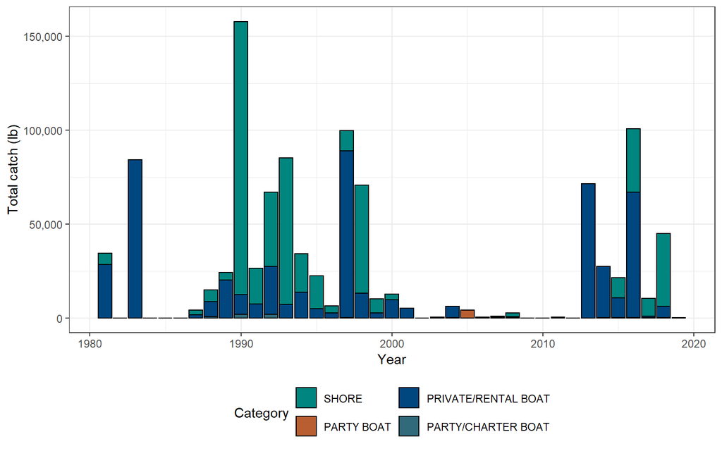

### Length

Length data were pulled from `survdat`. Only years with more than 10 fish lengths were considered for analysis. Separate geom_gls() functions were fit for the minimum, mean, and maximum lengths; trend lines are only shown when the trend was statistically significant, so some plots may have fewer than three trend lines. Please note, sometimes the survey observed a small number of fish outside of the defined stock area.

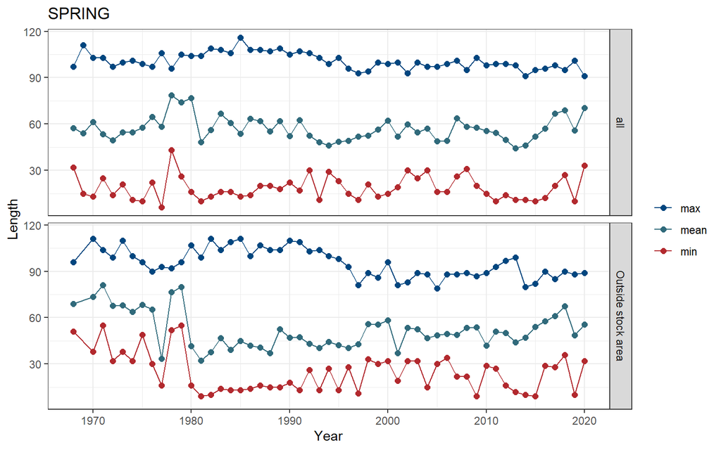

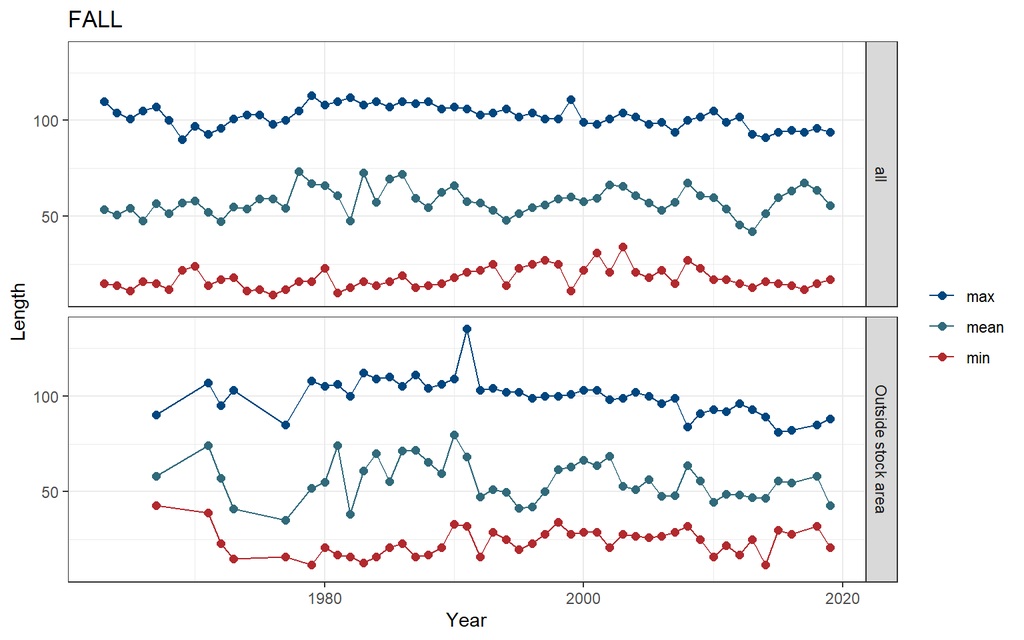

| Season | Region | Mean value +- SD (n fish, n years) | Mean value +- SD (n fish, past 5 years) | Range (total) | Range (past 5 years) |
| --- | --- | --- | --- | --- | --- |
| FALL | all | 57.39 +- 18.45 (58,816, 57) | 60.9 +- 15.69 (11,845, 5) | 9 - 113 | 12 - 96 |
| FALL | Outside stock area | 53.24 +- 19.04 (14,253, 45) | 52.64 +- 13.98 (1,859, 4) | 12 - 135 | 21 - 88 |
| SPRING | all | 55.15 +- 17.91 (62,872, 53) | 61.6 +- 16.21 (9,801, 5) | 6 - 116 | 10 - 101 |
| SPRING | Outside stock area | 43.55 +- 15.94 (31,805, 52) | 57.53 +- 16.16 (1,294, 5) | 9 - 111 | 10 - 90 |

### Condition

Condition information comes from [diet data](https://github.com/Laurels1/Condition/blob/master/data/allfh.RData).

#### Length vs weight

Length vs weight for all geographic samples by decade. Please note, no trend lines were fit, points are jittered to reduce overlap, and sometimes the survey observed a small number of fish outside of the defined stock area.

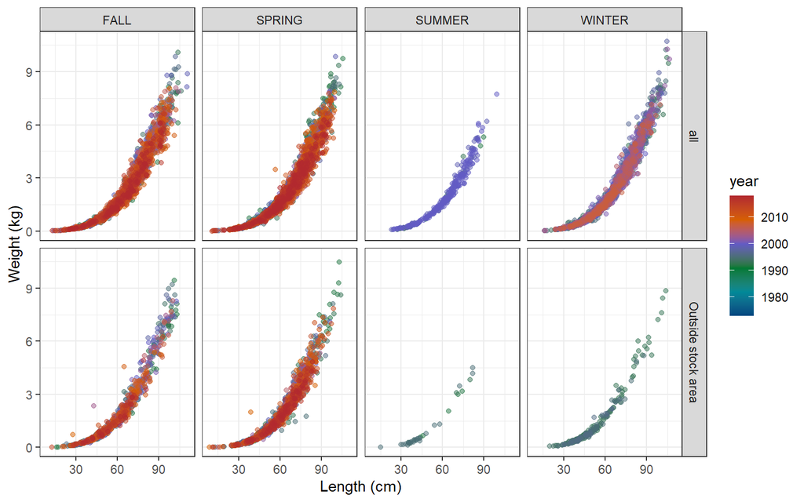

#### Condition factor

##### Weight-volume

We calculated a rough condition factor as: Weight / Length^3. If there were more than 30 years of data, a geom_gls() regression was fit. In order to fit the geom_gls() regression, we calculated the mean condition factor for each year and plotted the geom_gls() through those points. Please note, points are jittered to reduce overlap, and sometimes the survey observed a small number of fish outside of the defined stock area.

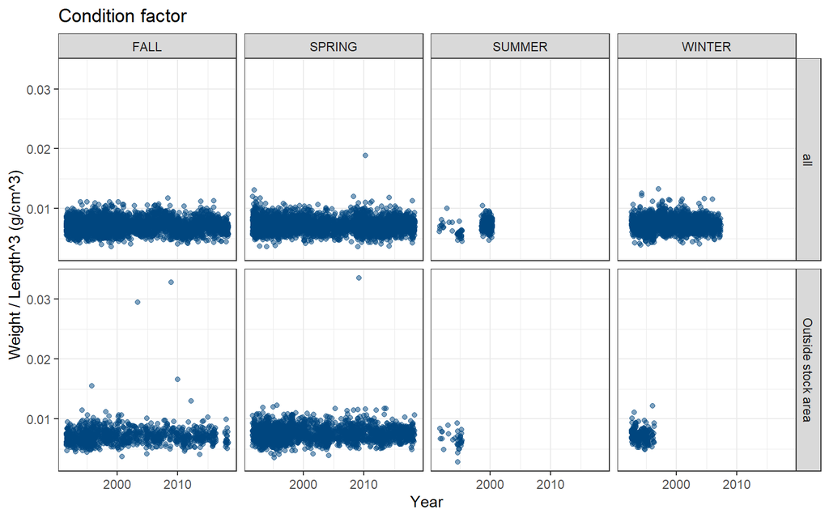

##### Relative weight

Relative weight was [previously calculated](https://github.com/Laurels1/Condition/tree/master/data). Please note, this data is aggregated by Ecological Protection Unit (EPU), which may differ slightly from the stock assessment regions.

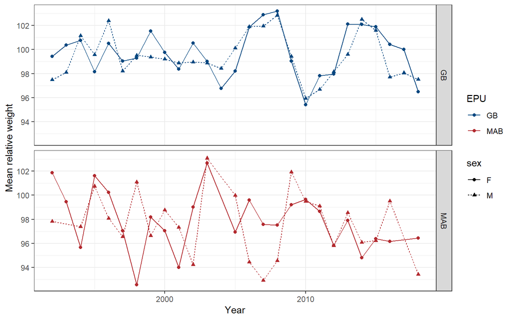

## Risk analysis

A preliminary risk analysis was conducted by ranking all species according to their indicator values. A high rank number and a normalized rank near 1 indicates that the species is at risk or of importance based on the measured indicator values. When a species was missing an indicator, it was assigned a normalized rank of 0.5.

Winter skate

| Region | Indicator | Year | Value | Rank | Normalized_rank |
| --- | --- | --- | --- | --- | --- |
| Georges Bank / Southern New England | bbmsy | 2018 | 1.28 | 5 out of 23 | 0.22 |
| Georges Bank / Southern New England | asmt_catch | 1990 | 18,876.00 | 24 out of 34 | 0.71 |
| Georges Bank / Southern New England | biomass_fall | mean of last 10 years vs historic mean | 2.01 | 17 out of 51 | 0.33 |
| Georges Bank / Southern New England | biomass_spring | mean of last 10 years vs historic mean | 1.33 | 22 out of 51 | 0.43 |
| Georges Bank / Southern New England | avg_length_fall | mean of last 10 years vs historic mean | 0.92 | 29 out of 51 | 0.57 |
| Georges Bank / Southern New England | avg_length_spring | mean of last 10 years vs historic mean | 0.97 | 18 out of 51 | 0.35 |
| Georges Bank / Southern New England | max_length_fall | mean of last 10 years vs historic mean | 0.98 | 24 out of 51 | 0.47 |
| Georges Bank / Southern New England | max_length_spring | mean of last 10 years vs historic mean | 0.98 | 22 out of 51 | 0.43 |
| Georges Bank / Southern New England | diet | all | 13.00 | 3 out of 11 | 0.27 |
| Georges Bank / Southern New England | rec_catch | average of 2014 - 2019 data | 44,358.00 | 15 out of 31 | 0.48 |
| Georges Bank / Southern New England | overall | all | 5.77 | 17 out of 53 | 0.32 |